# Crystal Lake Metabolism

### DO%sat and DO mass:

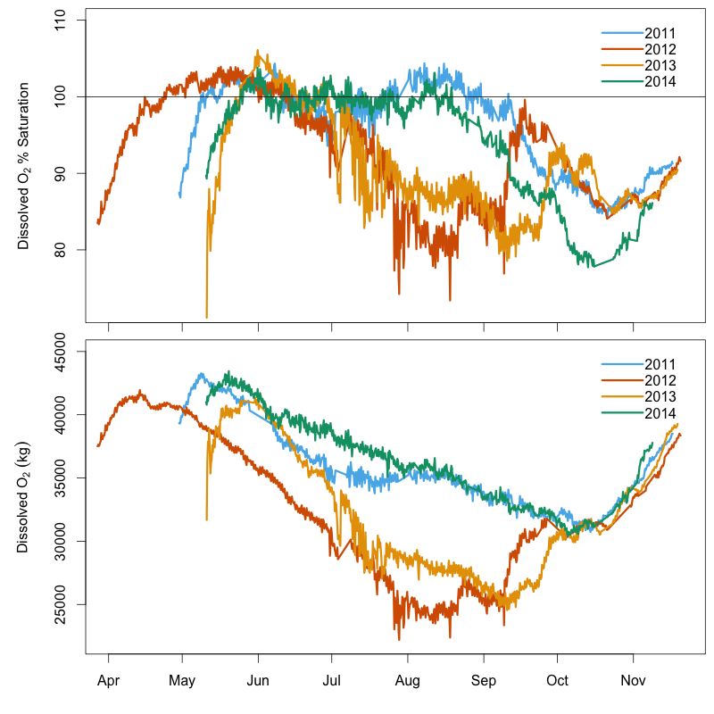

Figure 1. Volume weighted dissolved oxygen percent saturation (A) and total dissolved oxygen mass (B).

### NEP:

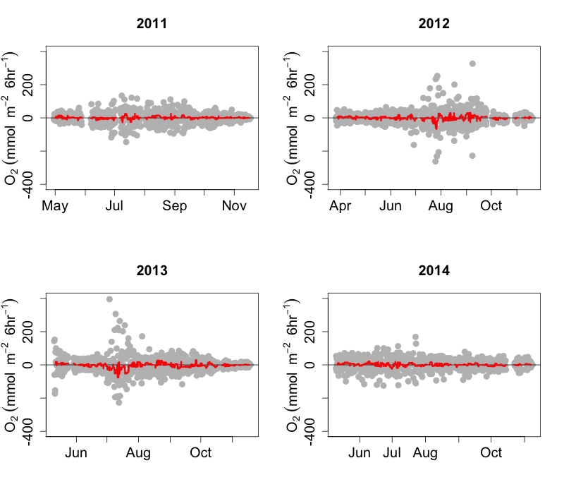

Figure 2. Six-hour depth integrated NEP (grey points) and 3 day moving median (red line). Missing data was filled with the monthly average before smoothing. NEP = delta.O2 - flux.O2, where delta.O2 is the change in the areal whole lake dissolved oxygen between consecutive 6-hour profiles, and flux.O2 is the O2 flux between the atmosphere and lake calculated every minute and integrated over the 6 hour period between profiles. The k.gas model used for calculation is Cole and Caraco 1998.

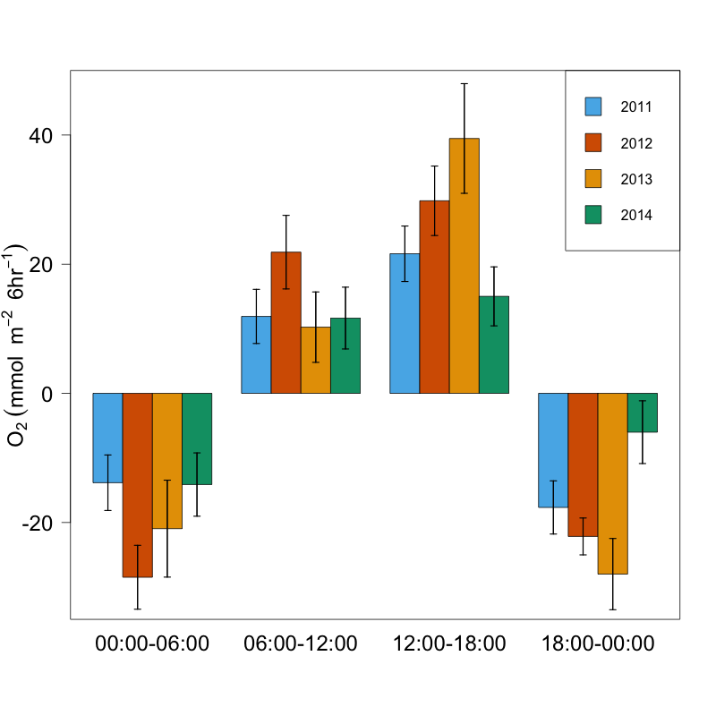

Figure 3. Annual averages of 6-hour depth integrated NEP grouped to 6-hour interval. Error bars denote standard error not corrected for autocorrelation.

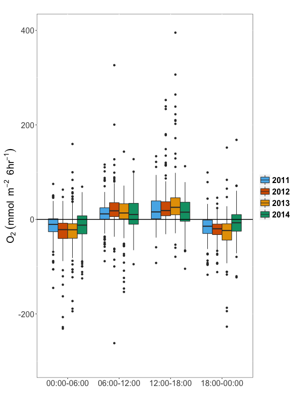

Figure 3.2. Six-hour depth integrated NEP grouped to 6-hour period for each year.

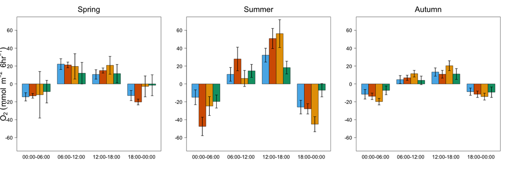

Figure 3.3. Annual averages of 6-hour depth integrated NEP grouped to each 6-hour interval and to season. Error bars denote standard error not corrected for autocorrelation. Spring = ice-off to summer solstice; Summer = summer solstice to fall equinox; Fall = fall equinox to mid-November.

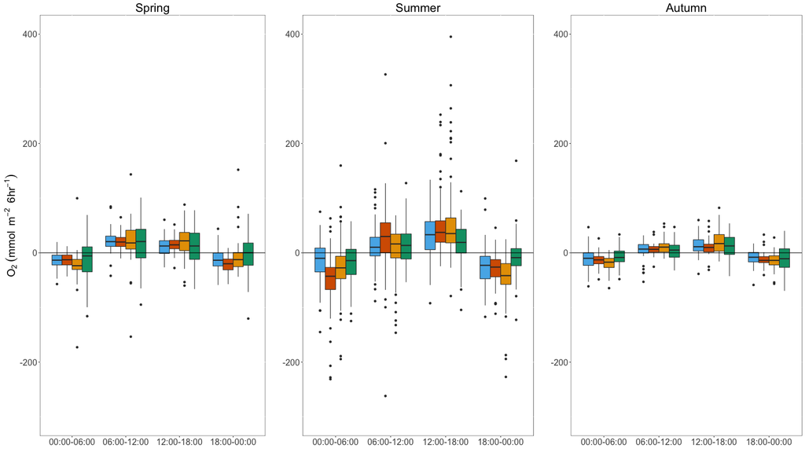

Figure 3.4. Six-hour depth integrated NEP grouped to 6-hour interval and to season.

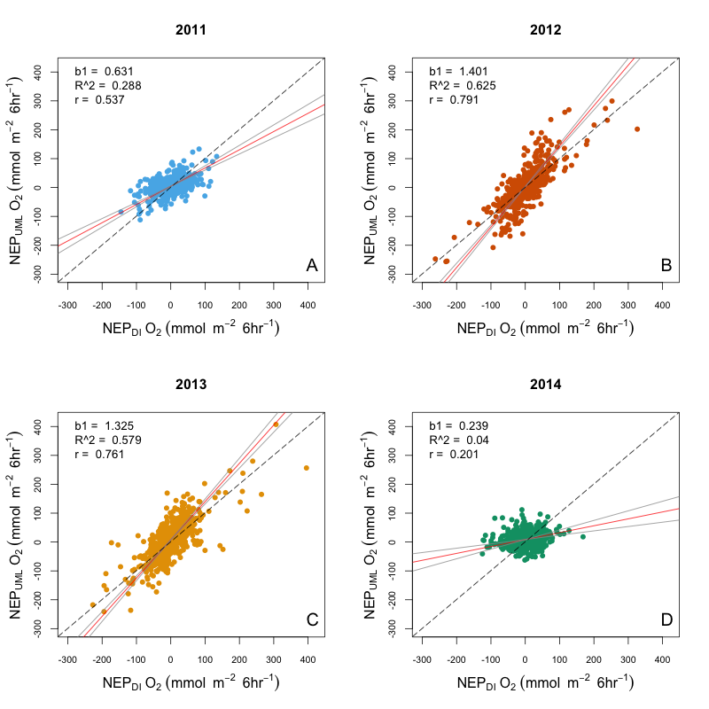

Figure 4. Upper mixed layer NEP vs. depth integrated NEP for the full open water period of each year. NEP is of 6-hour resolution. Dashed line is 1:1. Solid red line is the type II major axis regression line bounded by confidence intervals. Regression slope, R^2, and correlation coefficient are presented.

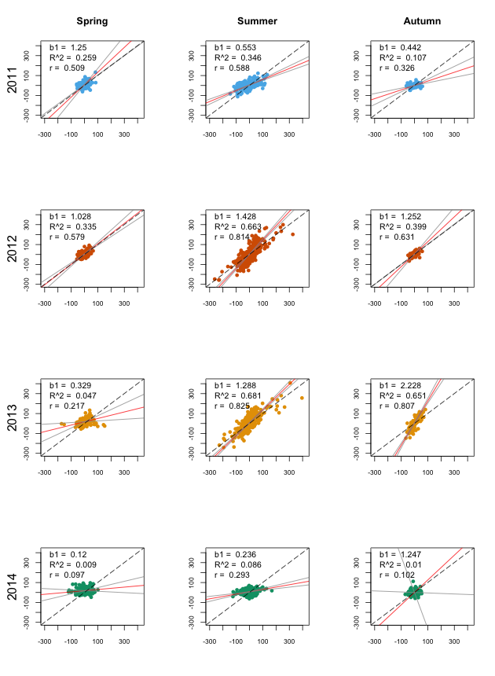

Figure 4.2. NEP.uml vs. NEP.di grouped by season and year. Spring = ice-off to summer solstice; Summer = summer solstice to fall equinox; Fall = fall equinox to mid-November. NEP is of 6-hour resolution. Dashed line is 1:1. Solid red line is the type II major axis regression line bounded by confidence intervals. Regression slope, R^2, and correlation coefficient are presented.

[figure not shown]

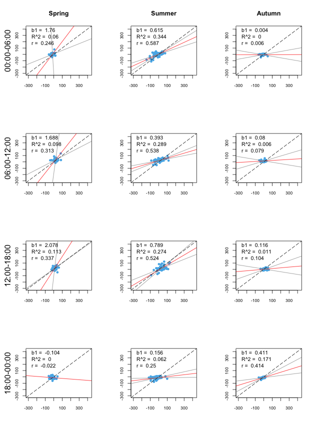

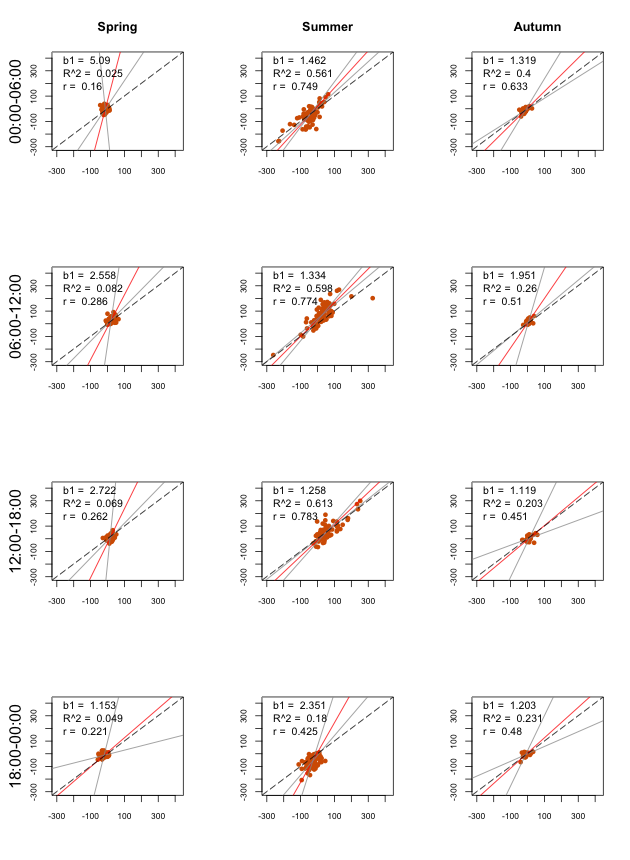

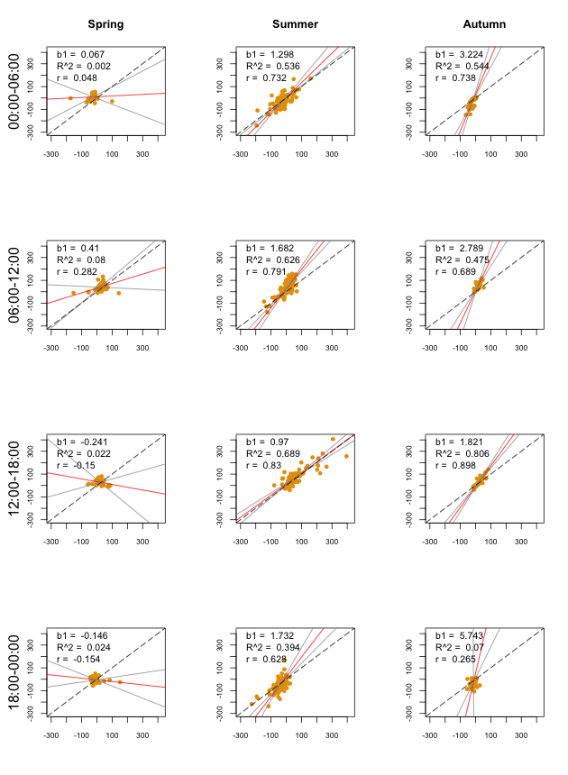

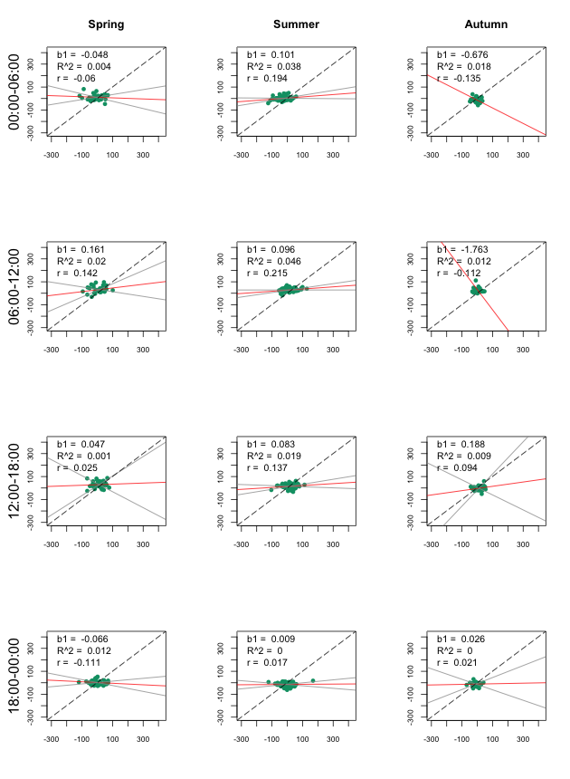

Figure 4.3. Six-hour NEP.uml vs. NEP.di grouped by 6-hour interval and season. Data point colors accord with previous figures. Dashed line is 1:1. Solid red line is the type II major axis regression line bounded by confidence intervals. Regression slope, R^2, and correlation coefficient are presented.

### GPP & R:

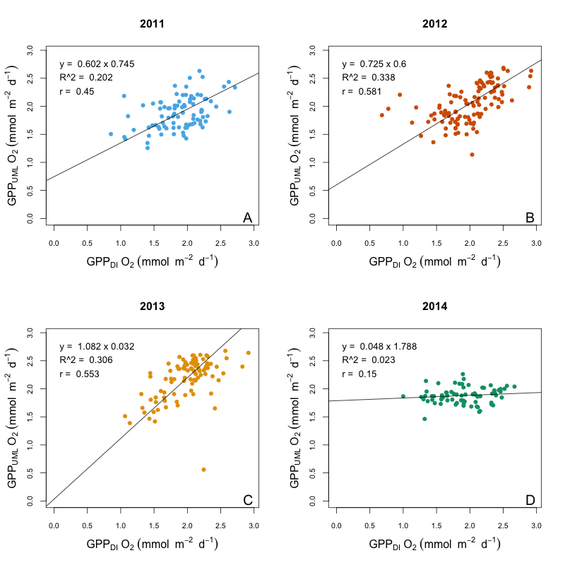

Figure 5. Daily GPP.uml vs. GPP.di for the full open water period. GPP.di is estimated from NEP.di during 06:00-12:00 and 12:00-18:00, and NEP.di throughout 00:00-06:00 of each day. Note data have been log transformed to meet assumptions of type II major axis regression. Negative values of GPP have been omitted. Solid line is the type II major axis regression. Regression equation and correlation coefficient are presented.

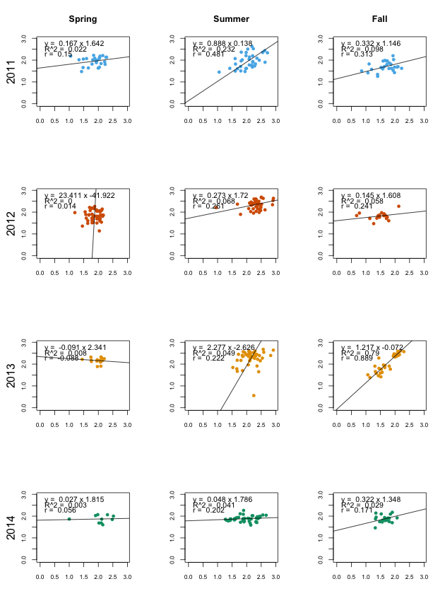

Figure 5.2. Daily GPP.uml vs. GPP.di grouped by season. Spring = ice-off to summer solstice; Summer = summer solstice to fall equinox; Fall = fall equinox to mid-November. GPP is of daily resolution. Negative values of GPP have been omitted. Data have been log transformed to meet assumptions of type II major axis regression. Solid line is the type II major axis regression. Regression equation and correlation coefficient are presented.

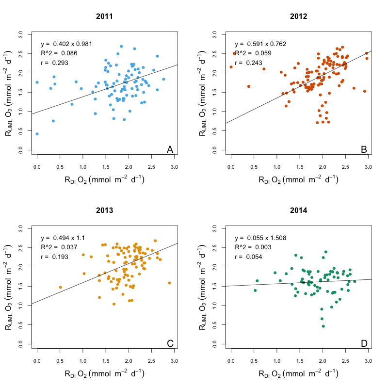

Figure 6. Daily R.uml vs. R.di for the full open water period. Depth integrated R is estimated from NEP.di throughout the 00:00-06:00 period of each day. Note data have been log transformed to meet assumptions of type II major axis regression. Days of bad estimates have been omitted, where “bad” estimates are considered R < 0. Solid line is the type II major axis regression. Regression equation and correlation coefficient are presented.

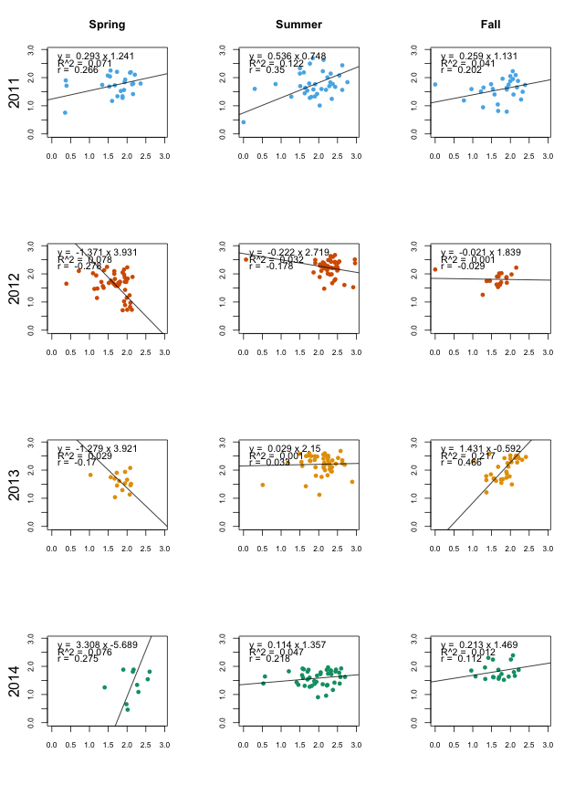

Figure 6.2. R.uml vs. R.di grouped by season. R is of daily resolution. Days of bad estimates have been omitted, where “bad” estimates are considered R < 0. Spring = ice-off to summer solstice; Summer = summer solstice to fall equinox; Fall = fall equinox to mid-November. Data have been log transformed to meet assumptions of type II major axis regression. Solid line is the type II major axis regression. Regression equation and correlation coefficient are presented.